# NYPD Shooting Incident Report

### Model Data

Let’s see if we can create a model that can tell us about the total number of deaths each year.

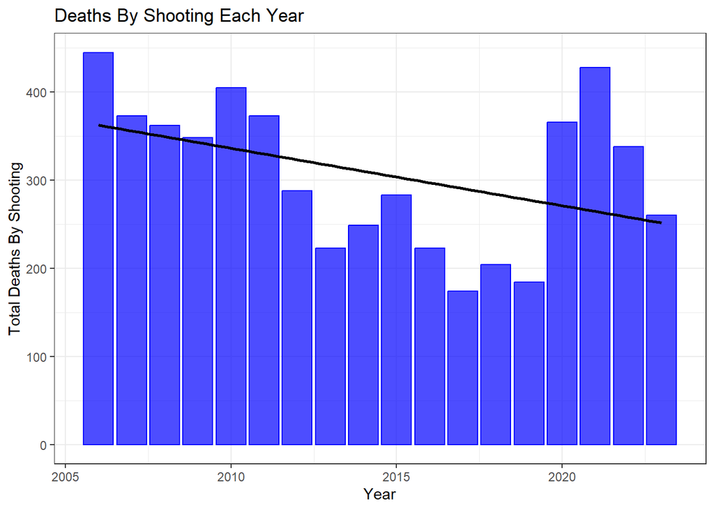

```r
murders_by_year <- shooting_data %>%
  mutate(OCCUR_YEAR = year(OCCUR_DATE),
         STATISTICAL_MURDER_FLAG = as.factor(STATISTICAL_MURDER_FLAG),
         MURDER_CODE = if_else(STATISTICAL_MURDER_FLAG == "TRUE", 1, 0)) %>%
  select(OCCUR_YEAR, MURDER_CODE) %>%
  group_by(OCCUR_YEAR) %>%
  summarize(TOTAL_MURDERS = sum(MURDER_CODE))

murders_by_year %>%
  ggplot(aes(OCCUR_YEAR, TOTAL_MURDERS)) +
  geom_col(color = "blue", fill = "blue", alpha = 0.7) +
  geom_smooth(method = lm, alpha = 0, color = "black") +
  theme_bw() +
  labs(title = "Deaths By Shooting Each Year",
       x = "Year",
       y = "Total Deaths By Shooting")
```

### Conclusion and Bias Identification

#### Bias Identification

As with any data analysis project, bias certainly played a role in how I decided to clean, visualize, analyze, and model this data set.

1. The variables I chose to omit.
- I omitted variables that I deemed unimportant to my analysis.
- Another person might have selected different variables to omit.
2. The variables I chose to utilize in my analysis.
- I only used a handful of variables from this data set in my analysis based on what I thought would be interesting.
- Another person might have selected different variables to analyze based on their interests and biases.
3. What I chose to do with missing and invalid data.
- This is always a subject of controversy. I decided to utilize the existing formatting within the data set and recode all missing values as “UNKNOWN”. I also looked through the data to see if there were any values that seemed to be typos or that were invalid for any other reason. I also recoded these values as “UNKNOWN”.
- Another person might have chosen to do this differently, but I used my best judgment (which, of course, is riddled with bias).
4. How I chose to analyze the data.
- For example, I chose not to analyze the *proportion* of incidents that occurred in each borough relative to that borough’s population. Rather, I decided to simply analyze the *total number* of incidents in each borough with no consideration for population. That was my decision based on what I thought would be interesting, but another person might have decided otherwise.
- I chose to focus mostly on the relationship between date and time data. This was for a few reasons, but mostly because they were some of the only variables in the data set that were not simple, nominal variables (e.g., sex, race, borough). I thought this would make the analysis more interesting as it allowed me to utilize scatter plots, which I would not have been able to do otherwise.

Although my own personal biases are evident throughout this document, my awareness of these biases allowed me to try things that I otherwise might not have, as well as to consider relationships that I otherwise might not have.

End.